# Multiple Regression Review

October 14, 2020

## Data Context

- Most college courses conclude with anonymous student evaluations.
- Evaluations as an indicator of course quality and teaching effectiveness is often criticized.
- Evaluation scores may reflect the influence of non-teaching related characteristics, such as the physical appearance.

These data contain observations on 463 courses at the University of Texas Austin, with 23 variables recorded in the data:

- information about the course
- information about the professor
- information about number of students
- information about the “attractiveness” rating of the professor

## Simple Linear Regression Review

We can model the relationship between a professor’s evaluation score (`score`) and their average attractiveness score (`bty_avg`) with a simple linear regression!

- Scores for average beauty can range from 0 to 10
- Evaluation scores can range from 1 to 5

**What are the model conditions we need to check for a simple linear regression?**

## Visualizing SLR

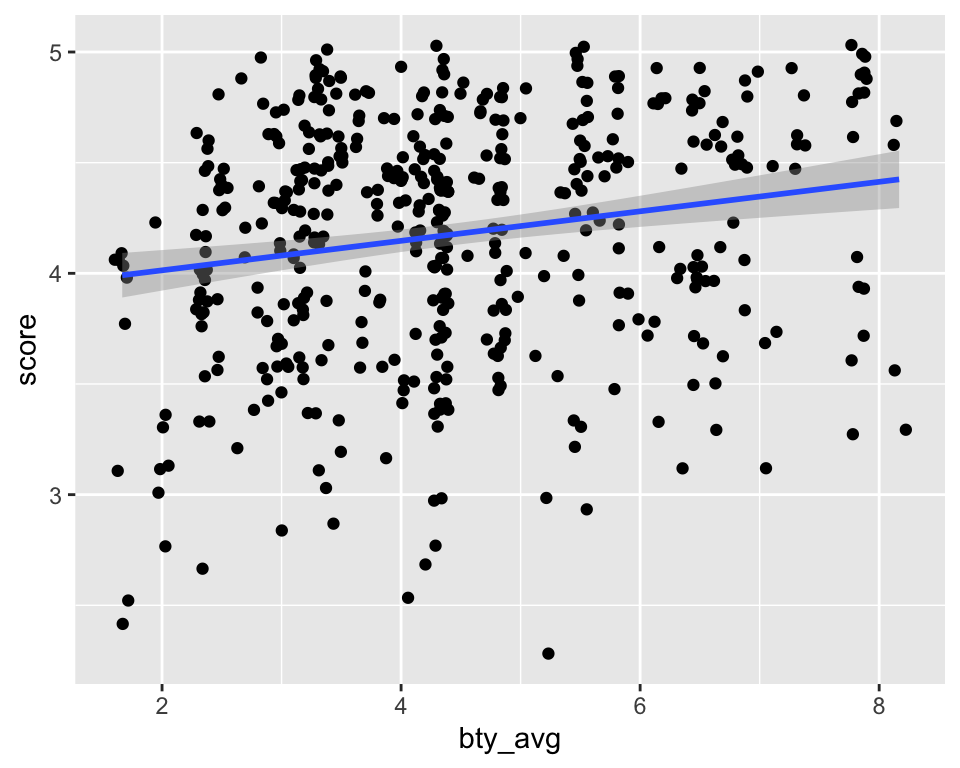

```r
evals %>%
  ggplot(aes(x = bty_avg, y = score)) +
  geom_jitter() +
  geom_smooth(method = "lm")
```

## Fitting a SLR Model

```r
model1 <- lm(score ~ bty_avg, data = evals)

get_regression_table(model1)
```

```
## # A tibble: 2 x 7
##   term      estimate std_error statistic p_value lower_ci upper_ci
##   <chr>        <dbl>     <dbl>     <dbl>   <dbl>    <dbl>    <dbl>
## 1 intercept    3.88      0.076     51.0        0    3.73     4.03
## 2 bty_avg      0.067     0.016      4.09       0    0.035    0.099
```

**How would we interpret the intercept and slope from this model?**

## Multiple Linear Regression

In multiple regression we include **multiple** explanatory variables, which can be categorical or quantitative.

- Categorical variables lead to different regression lines
- Quantitative variables lead to different planes in dataspace

**In this course, we will mainly stick to regression models with one quantitative and one categorical explanatory variables.**

## Visualization

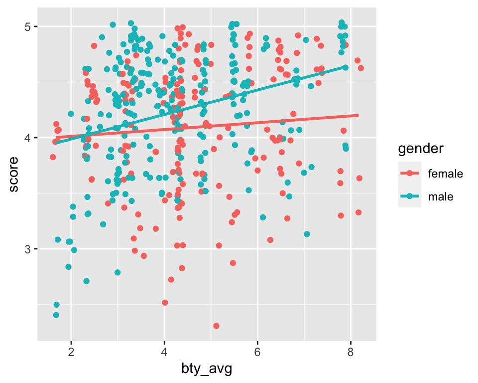

```r
evals %>%
  ggplot(aes(x = bty_avg, y = score, color = gender)) +
  geom_jitter() +
  geom_smooth(method = "lm", se = FALSE)
```

## Modeling Options

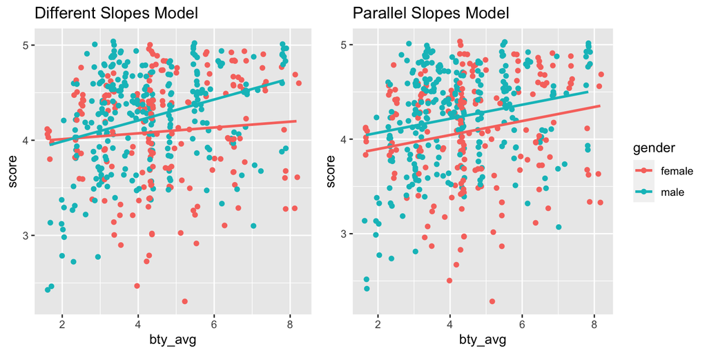

## Fitting a Parallel Slopes Model

```r
model2 <- lm(score ~ bty_avg + gender, data = evals)

get_regression_table(model2)
```

```
## # A tibble: 3 x 7
##   term       estimate std_error statistic p_value lower_ci upper_ci
##   <chr>         <dbl>     <dbl>     <dbl>   <dbl>    <dbl>    <dbl>
## 1 intercept     3.75      0.085     44.3    0        3.58     3.91
## 2 bty_avg       0.074     0.016      4.56   0        0.042    0.106
## 3 gendermale    0.172     0.05       3.43   0.001    0.074    0.271
```

## Interpreting a Parallel Slopes Model

```
## # A tibble: 3 x 7
##   term       estimate std_error statistic p_value lower_ci upper_ci
##   <chr>         <dbl>     <dbl>     <dbl>   <dbl>    <dbl>    <dbl>
## 1 intercept     3.75      0.085     44.3    0        3.58     3.91
## 2 bty_avg       0.074     0.016      4.56   0        0.042    0.106
## 3 gendermale    0.172     0.05       3.43   0.001    0.074    0.271
```

- What does the estimate labeled `gendermale` correspond to?
- Who does the `intercept` correspond to?
- What this relationship between evaluation score and average beauty score for the professors in these data?

## Calculating the Different Lines

| Gender | Intercept | Slope for average beauty |
| --- | --- | --- |
| Female | 3.75 | 0.074 |
| Male | 3.75 + 0.172 = 3.922 | 0.074 |

## Writing a Parallel Slopes Model

\[ \widehat{score} = 3.75 + 0.172 \cdot 1_{\text{is male}} + 0.074 \cdot bty\_avg \] where

\[ 1_{\text{is male}} = \begin{cases} 1, & \text{ if professor identified as male} \\ 0, & \text{ if professor identified as female} \end{cases} \]

## “Offsets”

The Modern Dive book refers to the adjustments in the intercept and slope for different levels of a categorical variable “offsets.”

- These describe how the regression line changes when moving from one group to another.
- Intercept offsets change the estimated mean evaluation score when an average beauty score is 0.
- Slope offsets modify the estimated change in the mean evaluation score when the average beauty score is increased by 1.

## Fitting a Different Slopes Model

```r
model3 <- lm(score ~ bty_avg + gender + bty_avg:gender, data = evals)

get_regression_table(model3)
```

```
## # A tibble: 4 x 7
##   term               estimate std_error statistic p_value lower_ci upper_ci
##   <chr>                 <dbl>     <dbl>     <dbl>   <dbl>    <dbl>    <dbl>
## 1 intercept             3.95      0.118     33.5    0        3.72     4.18
## 2 bty_avg               0.031     0.024      1.28   0.202   -0.017    0.078
## 3 gendermale           -0.184     0.153     -1.20   0.232   -0.485    0.118
## 4 bty_avg:gendermale    0.08      0.032      2.45   0.015    0.016    0.143
```

## Interpreting a Different Slopes Model

```
## # A tibble: 4 x 3
##   term               estimate std_error
##   <chr>                 <dbl>     <dbl>
## 1 intercept             3.95      0.118
## 2 bty_avg               0.031     0.024
## 3 gendermale           -0.184     0.153
## 4 bty_avg:gendermale    0.08      0.032
```

- Who does the `bty_avg` estimate correspond to?
- What does the estimate labeled `bty_avg:gendermale` correspond to?

## Calculating the Different Lines

| Gender | Intercept | Slope for average beauty |
| --- | --- | --- |
| Female | 3.95 | 0.031 |
| Male | 3.95 - 0.184 = 3.766 | 0.031 + 0.08 = 0.111 |

## Writing a Different Slopes Model

\[ \widehat{score} = 3.95 - 0.184 \cdot 1_{\text{is male}} + 0.031 \cdot bty\_avg \\ + 0.08 \cdot 1_{\text{is male}} \cdot bty\_avg \] where

\[ 1_{\text{is male}} = \begin{cases} 1, & \text{ if professor identified as male} \\ 0, & \text{ if professor identified as female} \end{cases} \]

- Male Professors: \[ \widehat{score} = 3.766 + 0.111 \cdot bty\_avg \]
- Female Professors: \[ \widehat{score} = 3.95 + 0.031 \cdot bty\_avg \]

## Your Turn

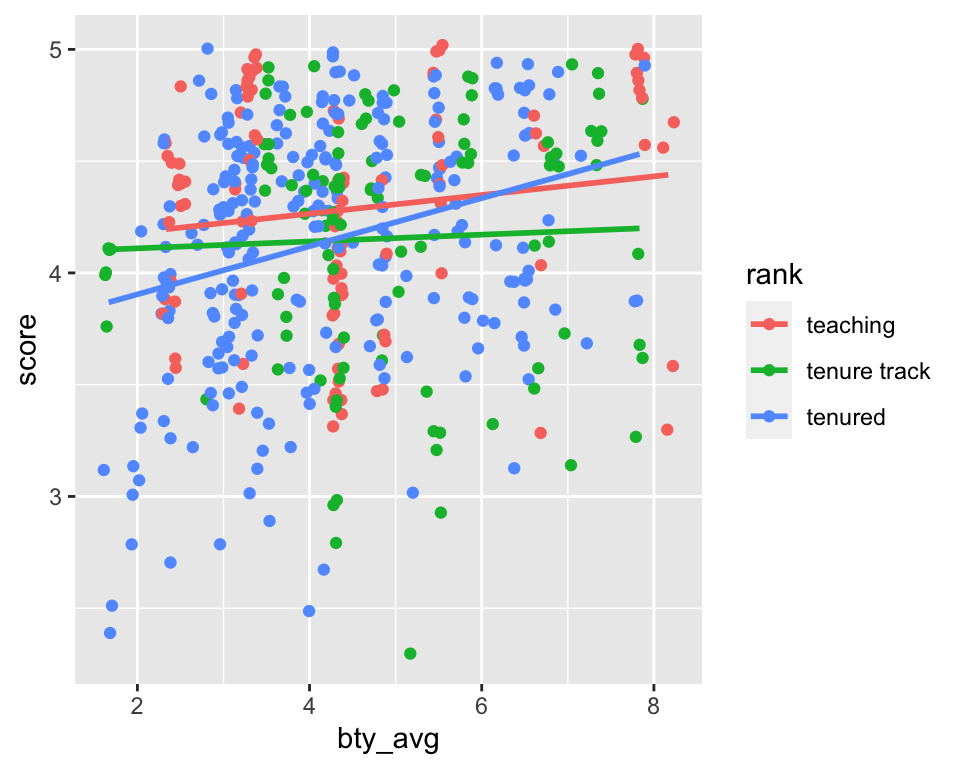

```r
evals %>%
  ggplot(aes(x = bty_avg, y = score, color = rank)) +
  geom_jitter() +
  geom_smooth(method = "lm", se = FALSE)
```

**Does it seem reasonable to use a different slopes model?**

```r
model4 <- lm(score ~ bty_avg + rank + bty_avg:rank, data = evals)

get_regression_table(model4)
```

```
## # A tibble: 6 x 3
##   term                     estimate std_error
##   <chr>                       <dbl>     <dbl>
## 1 intercept                   4.10      0.15
## 2 bty_avg                     0.042     0.031
## 3 ranktenure track           -0.019     0.23
## 4 ranktenured                -0.409     0.182
## 5 bty_avg:ranktenure track   -0.026     0.046
## 6 bty_avg:ranktenured         0.066     0.039
```

- What is the estimated regression line for teaching faculty?
- What is the estimated regression line for tenure-track faculty?
- What is the estimated regression line for tenured faculty?